# Practical Machine Learning Project

## Description

In this project, we are going to use data from accelerometers on the belt, forearm, arm, and dumbell of 6 participants. They were asked to perform barbell lifts correctly and incorrectly in 5 different ways. More information is available from the website here: http://groupware.les.inf.puc-rio.br/har

Our goal is to predict the manner in which they did the exercise. We will built our training model, and use our prediction model to predict 20 different test cases.

The training data for this project comes from here:

https://d396qusza40orc.cloudfront.net/predmachlearn/pml-training.csv

The testing data for this project comes from here:

https://d396qusza40orc.cloudfront.net/predmachlearn/pml-testing.csv

## Exploring Dataset

```r
if(!file.exists("pml-training.csv"))
        download.file("https://d396qusza40orc.cloudfront.net/predmachlearn/pml-training.csv", "pml-training.csv")
if(!file.exists("pml-testing.csv"))
        download.file("https://d396qusza40orc.cloudfront.net/predmachlearn/pml-testing.csv", "pml-testing.csv")

training <- read.csv("pml-training.csv", na.strings = c("NA", ""))
testing <- read.csv("pml-testing.csv", na.strings = c("NA", ""))

head(training)
```

[output not shown]

## Data Cleaning

```r
naColumns <- function(x){
        col_drops <- c()
        for(i in 1:ncol(x)){
                # if NA amount > 50% of total
                if(length(which(is.na(x[, i]))) > nrow(x)/2)
                    col_drops <- c(col_drops, colnames(x)[i])
        }
        col_drops
}

col_drops_training <- naColumns(training)
col_drops_testing <- naColumns(testing)
```

Check if training and testing has same NA columns

```r
all(col_drops_training == col_drops_testing)
```

```
## [1] TRUE
```

Drop NA columns and first 7 columns that are useless for predicting

```r
training <- training[, -which(names(training) %in% col_drops_training)]
training <- training[, 8:ncol(training)]
testing <- testing[, -which(names(testing) %in% col_drops_testing)]
testing <- testing[, 8:(ncol(testing)-1)]
dim(training)
```

```
## [1] 19622    53
```

```r
dim(testing)
```

```
## [1] 20 52
```

## Training

```r
library(lattice)
library(ggplot2)
library(caret)
library(rpart)
library(rpart.plot)
library(rattle)
library(randomForest)
```

```r
set.seed(123)
inTrain <- createDataPartition(training$classe, p = 0.75, list = FALSE)
myTraining <- training[inTrain, ]
myTesting <- training[-inTrain, ]
```

Modeling via rpart and classification tree

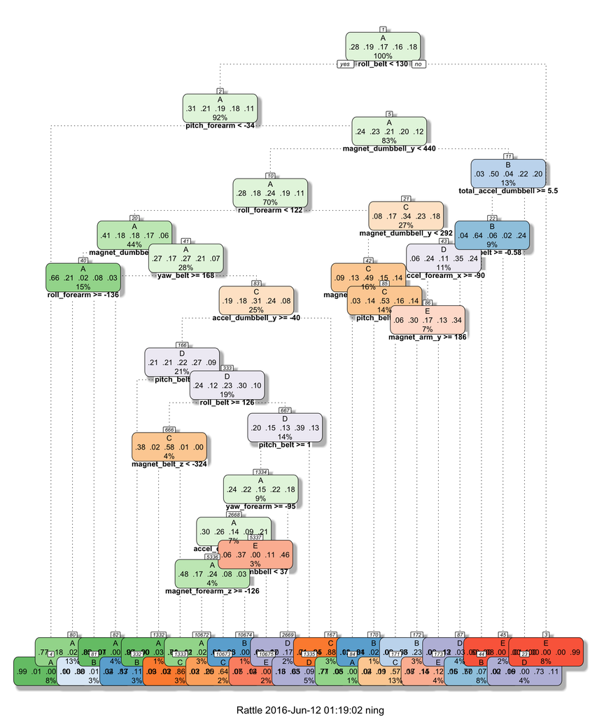

```r
fit <- rpart(classe ~ ., data = myTraining, method = "class")
fancyRpartPlot(fit, cex = 0.75)
```

```r
pred_class <- predict(fit, myTesting, type = "class")
confusionMatrix(pred_class, myTesting$classe)
```

```
## Confusion Matrix and Statistics
##
##           Reference
## Prediction    A    B    C    D    E
##          A 1237  131   16   44   15
##          B   45  598   72   67   71
##          C   39  102  683  134  115
##          D   51   64   65  499   46
##          E   23   54   19   60  654
##
## Overall Statistics
##
##                Accuracy : 0.7486
##                  95% CI : (0.7362, 0.7607)
##     No Information Rate : 0.2845
##     P-Value [Acc > NIR] : < 2.2e-16
##
##                   Kappa : 0.6817
##  Mcnemar's Test P-Value : < 2.2e-16
##
## Statistics by Class:
##
##                      Class: A Class: B Class: C Class: D Class: E
## Sensitivity            0.8867   0.6301   0.7988   0.6206   0.7259
## Specificity            0.9413   0.9355   0.9037   0.9449   0.9610
## Pos Pred Value         0.8572   0.7011   0.6365   0.6883   0.8074
## Neg Pred Value         0.9543   0.9134   0.9551   0.9270   0.9397
## Prevalence             0.2845   0.1935   0.1743   0.1639   0.1837
## Detection Rate         0.2522   0.1219   0.1393   0.1018   0.1334
## Detection Prevalence   0.2942   0.1739   0.2188   0.1478   0.1652
## Balanced Accuracy      0.9140   0.7828   0.8513   0.7828   0.8434
```

The Accuracy is 0.74, it looks like not good enough to be acceptable.

Modeling via Random forest, use cross validation

```r
fit_rf <- train(classe ~ ., data = myTraining, method = "rf",
                trControl = trainControl(method = "cv", number = 4))
pred_rf <- predict(fit_rf, myTesting)
confusionMatrix(pred_rf, myTesting$classe)
```

```
## Confusion Matrix and Statistics
##
##           Reference
## Prediction    A    B    C    D    E
##          A 1394    3    0    0    0
##          B    1  943    9    0    0
##          C    0    3  846   19    0
##          D    0    0    0  784    2
##          E    0    0    0    1  899
##
## Overall Statistics
##
##                Accuracy : 0.9923
##                  95% CI : (0.9894, 0.9945)
##     No Information Rate : 0.2845
##     P-Value [Acc > NIR] : < 2.2e-16
##
##                   Kappa : 0.9902
##  Mcnemar's Test P-Value : NA
##
## Statistics by Class:
##
##                      Class: A Class: B Class: C Class: D Class: E
## Sensitivity            0.9993   0.9937   0.9895   0.9751   0.9978
## Specificity            0.9991   0.9975   0.9946   0.9995   0.9998
## Pos Pred Value         0.9979   0.9895   0.9747   0.9975   0.9989
## Neg Pred Value         0.9997   0.9985   0.9978   0.9951   0.9995
## Prevalence             0.2845   0.1935   0.1743   0.1639   0.1837
## Detection Rate         0.2843   0.1923   0.1725   0.1599   0.1833
## Detection Prevalence   0.2849   0.1943   0.1770   0.1603   0.1835
## Balanced Accuracy      0.9992   0.9956   0.9920   0.9873   0.9988
```

Random forest get better Accuracy: 0.99

## Prediction

Then use our Random forest prediction model to predict 20 different test cases

```r
prediction <- predict(fit_rf, testing)
prediction
```

```
##  [1] B A B A A E D B A A B C B A E E A B B B
## Levels: A B C D E
```